# HW3 - Kaggle Competition

## Dimensionality Reduction

- I consolidate the 222 x,y,z coordinates by using 222 unique PCAs.
- I take first principal component from each of the 222 x,y,z groupings.
- By swapping the principal component for the x,y,z grouping I reduce 666 variables to 222.
- I remove variables with near-zero variance, as they make classification tree algorithms unstable.

```r
dfcol1 <- as.data.frame(integer(nrow(df)))
tdcol1 <- as.data.frame(integer(nrow(td)))
for (i in 1:222){
  tempx <- paste("x", i, sep = "")
  tempy <- paste("y", i, sep = "")
  tempz <- paste("z", i, sep = "")

  dfPCA <- as.data.frame(cbind(df[,tempx],df[,tempy],df[,tempz]))
  tdPCA <- as.data.frame(cbind(td[,tempx],td[,tempy],td[,tempz]))
  temp.pca <- prcomp(dfPCA)
  dfPCApred <- as.data.frame(predict(temp.pca, newdata=dfPCA))
  tdPCApred <- as.data.frame(predict(temp.pca, newdata=tdPCA))

  pcacolname <- paste("pca", i, sep = "")

  names(dfPCApred)[names(dfPCApred)=="PC1"] <- pcacolname
  names(tdPCApred)[names(tdPCApred)=="PC1"] <- pcacolname

  dfcol1 <- cbind(dfcol1,dfPCApred)
  dfcol1$PC2 <- NULL
  dfcol1$PC3 <- NULL

  tdcol1 <- cbind(tdcol1,tdPCApred)
  tdcol1$PC2 <- NULL
  tdcol1$PC3 <- NULL
}
dfcol1 <- dfcol1[,-1]
tdcol1 <- tdcol1[,-1]
#remove near zero-variance predictors
remove_cols <- nearZeroVar(dfcol1, names = TRUE, freqCut = 2, uniqueCut = 20)
all_cols <- names(dfcol1)
dfcol1_small <- dfcol1[ , setdiff(all_cols, remove_cols)]
df.all <- cbind(dfcol1_small, dfcat)
td.all <- cbind(tdcol1, tdcat)
```

## Classification Algorithms

- I test three diferent classification algorithms with the *caret* package in R.
  - Gradient Boosted Trees
  - Random Forest
  - Extreme Gradient Boosting
- Caret uses cross validation for tuning, and allows easy comparison of multiple classification approaches.

## Exploratory Points - I apply the three different classification algorithms to the Titanic Dataset. XGB boost seems like the algorithm with the highest accuracy, with Random Forests also showing strong accuracy.

```r
df.titanic[complete.cases(df.titanic)]
```

[output not shown]

```r
control <- trainControl(method="repeatedcv", number=2, repeats=1, classProbs = TRUE)
set.seed(7)
modelGBM <- train(output ~ ., data = df.titanic, method='gbm', trControl=control, metric = "ROC", preProc = c("center", "scale"))
```

[output not shown]

[output not shown]

[output not shown]

[output not shown]

[output not shown]

[output not shown]

[output not shown]

```r
set.seed(7)
mtry <- sqrt(ncol(df.all))
tunegrid <- expand.grid(.mtry=mtry)
modelRF <- train(output ~ ., data = df.titanic, method="rf", metric="Accuracy", tuneGrid=tunegrid, trControl=control)
set.seed(7)
modelXGB <- train(output ~ ., data = df.titanic, method='xgbTree', trControl=control, metric = "Accuracy", preProc = c("center", "scale"))
```

[output not shown]

## Analysis of Results

- I compare box plots of the Accuracy and Kappa metrics
- Extreme Gradient Boosting has the highest Accuracy Ratio and Kappa.
- Variable importance shows that Gradient Boosting places more importance on categorical variables.
- Random Forest places more importance on continuous variables.

```r
results <- resamples(list(GBM=modelGBM, RF=modelRF, XGB=modelXGB))
summary(results)
```

```
Call:
summary.resamples(object = results)

Models: GBM, RF, XGB
Number of resamples: 2

Accuracy
         Min.   1st Qu.    Median      Mean   3rd Qu.      Max. NA's
GBM 0.8011204 0.8039216 0.8067227 0.8067227 0.8095238 0.8123249    0
RF  0.7983193 0.8046218 0.8109244 0.8109244 0.8172269 0.8235294    0
XGB 0.8179272 0.8214286 0.8249300 0.8249300 0.8284314 0.8319328    0

Kappa
         Min.   1st Qu.    Median      Mean   3rd Qu.      Max. NA's
GBM 0.5771201 0.5821759 0.5872318 0.5872318 0.5922877 0.5973436    0
RF  0.5819128 0.5934582 0.6050035 0.6050035 0.6165489 0.6280943    0
XGB 0.6093632 0.6177813 0.6261994 0.6261994 0.6346176 0.6430357    0
```

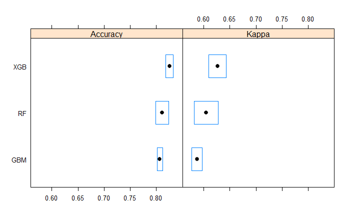

```r
bwplot(results)
```

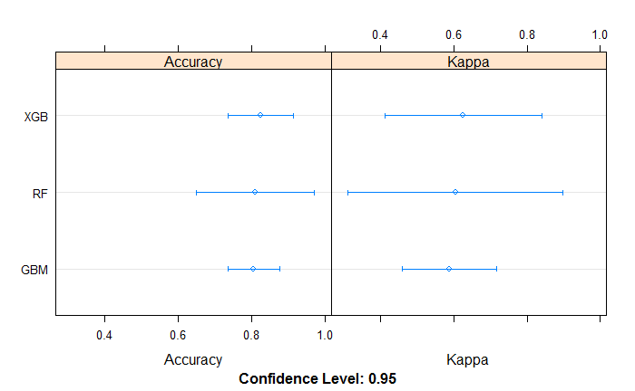

```r
dotplot(results)
```

```r
varImp(modelGBM)
```

```
gbm variable importance

           Overall
Sexmale   100.0000
Age        58.2716
Fare       53.9453
Pclass3    36.1927
EmbarkedC   3.6500
Pclass2     2.6018
SibSp4      2.0517
EmbarkedQ   1.8118
SibSp1      1.2177
EmbarkedS   0.8580
Parch2      0.7831
Parch1      0.4959
SibSp3      0.4692
SibSp2      0.3111
SibSp8      0.0000
Parch3      0.0000
Parch5      0.0000
Parch6      0.0000
Parch4      0.0000
SibSp5      0.0000
```

```r
varImp(modelRF)
```

```
rf variable importance

            Overall
Sexmale   100.00000
Age        88.92394
Fare       84.88438
Pclass3    30.31900
SibSp1      8.32163
Pclass2     6.00985
EmbarkedC   4.67246
Parch1      4.22363
EmbarkedS   3.59258
Parch2      2.94308
SibSp4      1.90590
SibSp3      1.76953
EmbarkedQ   1.43404
SibSp2      0.98918
SibSp5      0.60382
Parch5      0.50193
Parch3      0.27375
Parch4      0.25776
Parch6      0.02231
SibSp8      0.00000
```

```r
varImp(modelXGB)
```

```
xgbTree variable importance

           Overall
Sexmale   100.0000
Fare       46.9668
Age        31.0487
Pclass3    29.2304
Pclass2     4.2660
EmbarkedC   3.6884
SibSp1      2.0990
SibSp4      0.9227
SibSp3      0.8875
SibSp2      0.6304
Parch1      0.5345
Parch2      0.4426
EmbarkedS   0.4129
SibSp8      0.0000
EmbarkedQ   0.0000
Parch6      0.0000
Parch3      0.0000
SibSp5      0.0000
Parch4      0.0000
Parch5      0.0000
```

```r
varImp(modelXGB)
```

```
xgbTree variable importance

           Overall
Sexmale   100.0000
Fare       46.9668
Age        31.0487
Pclass3    29.2304
Pclass2     4.2660
EmbarkedC   3.6884
SibSp1      2.0990
SibSp4      0.9227
SibSp3      0.8875
SibSp2      0.6304
Parch1      0.5345
Parch2      0.4426
EmbarkedS   0.4129
Parch5      0.0000
EmbarkedQ   0.0000
Parch6      0.0000
Parch4      0.0000
SibSp8      0.0000
Parch3      0.0000
SibSp5      0.0000
```

# Kaggle Submission

[output not shown]